# HardWork2

Cortland Watson

# Total {25}

# Reading {16}

| Section | Points |
| --- | --- |
| 2.1 | 3 |
| 2.2 | 3 |
| 2.3 | 1 |
| 2.4 | 4 |
| 2.5 | 2 |
| 2.6 | 3 |

# Theory {3}

## Exercise 2.66 {3}

Five observations on $Y$ are to be taken when $X=4,8,12,16,$ and $20$, respectively. The true regression function is $E\{Y\}=20+4X$, and the $\epsilon_i$ are independent $N(0,25)$.

1. Generate five normal random numbers, with mean $0$ and variance $25$. Consider these random numbers as the error terms for the five $Y$ observations at $X=4,8,12,16,$ and $20$ and calculate $Y_1,Y_2, \dots, Y_5$. Obtain the least squares estimates $b_0$ and $b_1$ when fitting a straight line to the five cases. Also calculate $\widehat{Y}_h$ when $X_h=10$ and obtain a $95$ percent confidence interval for $E\{Y_h\}$ when $X_h=10$
2. Repeat part (a) 200 times, generating new random numbers each time.
3. Make a frequency distribution of the 200 estimates $b_1$. Calculate the mean and standard deviation of the 200 estimates of $b_1$. Are the results consistent with theoretical expectations?
4. What proportion of the 200 confidence intervals for $E\{Y_h\}$ when $X_h=10$ include $E\{Y_h\}$? Is the result consistent with theoretical expectations?

##### Work 2.66

### Solution

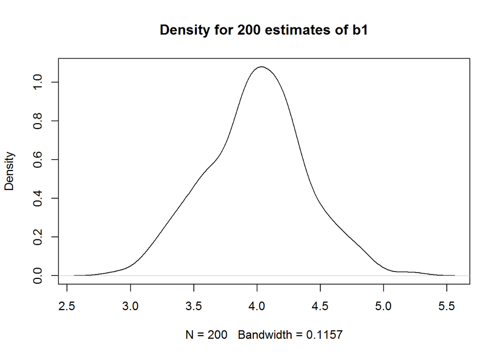

```r
plot(density(b1), main = "Density for 200 estimates of b1")
```

# Application {6}

## Exercise 2.4 {4}

```r
Ex2.4 <- read.table('http://www.stat.ufl.edu/~rrandles/sta4210/Rclassnotes/data/textdatasets/KutnerData/Chapter%20%201%20Data%20Sets/CH01PR19.txt', header=FALSE)
```

1. Obtain a 99 percent confidence interval for $\beta_1$. Interpret your confidence interval. Does it include zero? Why might the director of admissions be interested in whether the confidence interval includes zero?
2. Test, using the test statistic $t*$, whether or not a linear association exists between student’s ACT score ($X$) and GPA at the end of the freshman year($Y$). Use a level of significance of .01. State the alternatives, decision rule, and conclusion.
3. What is the $P$-value of your test in part(B)? How does it support the concludion reached in part(B)?

### Solution

1. The confidence interval for $\beta_1$ is as follows. This means that we are 99% confident that the true coefficient for ACT score predicting GPA falls in this interval. This does not include 0 which means that ACT does have something to say about GPA of freshman year. The school would have interest in this, to see if ACT scores really matter.

```r
pander(confint(GPA.lm, level=0.99))
```

|  | 0.5 % | 99.5 % |
| --- | --- | --- |
| **(Intercept)** | 1.274 | 2.954 |
| **V2** | 0.005386 | 0.07227 |

2. By running the $t$ test to see if there is a linear relationship between ACT score and GPA, we are able to find interesting information. We are able to see that the $t$ statistic, with a level of significance of 0.01 suggest that ACT score if a significant predictor, thus indicating a linear relationship.
3. The $P$-values for part (b) are found in the underlying table.

```r
pander(summary(GPA.lm))
```

|  | Estimate | Std. Error | t value | Pr(>\|t\|) |
| --- | --- | --- | --- | --- |
| **V2** | 0.03883 | 0.01277 | 3.04 | 0.002917 |
| **(Intercept)** | 2.114 | 0.3209 | 6.588 | 1.304e-09 |

Fitting linear model: V1 ~ V2

| Observations | Residual Std. Error | $R^2$ | Adjusted $R^2$ |
| --- | --- | --- | --- |
| 120 | 0.6231 | 0.07262 | 0.06476 |

## Exercise 2.10 {2}

For each of the following questions, explain whether a confidence interval for a mean response or a prediction interval for a new observation is appropriate. A) What will be the humidity level in this greenhouse tomorrow when we set the temperature level at 31 degrees celsius? B) How much do families whose disposable income is $23500 spend, on the average, for meals away from home? C) How many kilowatt-hours of electricity will be consumed next month by commercial and idustrial users in the Twin Cities service area, given that the index of business activity for the area remains at its present level?

### Solution

1. As we are looking to predict what will happen at a specific explanatory variable point, we are using a prediction interval to make an estimation at the specific outcome.
2. As we are looking to predict what will happen as a certain family demographic spends, we are looking at a group and considering the average of this group, we will therefore use a confidence interval.
3. This is the same type of situation as the one above. We are looking for an average of many observations, thus looking for a confidence interval.